# Problem Set 1

Due April 11th at 5:30pm -- at the start of the class so we can discuss the solutions in class.

### Before You Start

Make sure to at least take a basic tutorial in the IPython notebook, otherwise you'll be totally lost. For this problem set, you should download flights.csv.bz2 and weather.csv.bz2 datasets from Canvas (files-data). Rename the notebook to LASTNAME_FIRSTNAME-PS1.ipynb.

When done, please submit

1. the notebook itself
2. the rendered html or pdf of it.

## About the Problem Set:

This problem set is rather similar to ones used for R, dplyr, and flights data. Just we use python and pandas.

In this problem set you will perform a basic exploratory analysis on an example dataset, bringing to bear all of your new skills in data manipulation and visualization. You will be required to submit well commented python code, documenting all code used in this problem set, along with a write up answering all questions below. Use figures as appropriate to support your answers, and when required by the problem.

## Preliminaries

You should also make sure the following libraries load correctly (click on the box below and hit Ctrl-Enter)

```python
#IPython is what you are using now to run the notebook
import IPython
print( "IPython version:      %6.6s (need at least 1.0)" % IPython.__version__)

# Numpy is a library for working with Arrays
import numpy as np
print( "Numpy version:        %6.6s (need at least 1.7.1)" % np.__version__)

# SciPy implements many different numerical algorithms
import scipy as sp
print( "SciPy version:        %6.6s (need at least 0.12.0)" % sp.__version__)

# Pandas makes working with data tables easier
import pandas as pd
print( "Pandas version:       %6.6s (need at least 0.11.0)" % pd.__version__)

# Module for plotting
import matplotlib.pyplot as plt
import matplotlib
%matplotlib inline
# necessary for in-line graphics

# SciKit Learn implements several Machine Learning algorithms
import sklearn
print( "Scikit-Learn version: %6.6s (need at least 0.13.1)" % sklearn.__version__)
```

```
IPython version:       6.2.1 (need at least 1.0)
Numpy version:        1.14.0 (need at least 1.7.1)
SciPy version:         1.0.0 (need at least 0.12.0)
Pandas version:       0.22.0 (need at least 0.11.0)
Scikit-Learn version: 0.19.1 (need at least 0.13.1)
```

```python
## Let's read the data and print some summary information
## adjust the path for your file system!
flights_df= pd.read_csv('flights.csv.bz2')
```

```python
print (flights_df.shape)
print (flights_df.columns)
print (flights_df.dtypes)
```

```
(336776, 17)
Index(['Unnamed: 0', 'year', 'month', 'day', 'dep_time', 'dep_delay',
       'arr_time', 'arr_delay', 'carrier', 'tailnum', 'flight', 'origin',
       'dest', 'air_time', 'distance', 'hour', 'minute'],
      dtype='object')
Unnamed: 0      int64
year            int64
month           int64
day             int64
dep_time      float64
dep_delay     float64
arr_time      float64
arr_delay     float64
carrier        object
tailnum        object
flight          int64
origin         object
dest           object
air_time      float64
distance        int64
hour          float64
minute        float64
dtype: object
```

```python
flights_df.dest.unique()
flights_df.head(10)
```

|  | Unnamed: 0 | year | month | day | dep_time | dep_delay | arr_time | arr_delay | carrier | tailnum | flight | origin | dest | air_time | distance | hour | minute |
| --- | --- | --- | --- | --- | --- | --- | --- | --- | --- | --- | --- | --- | --- | --- | --- | --- | --- |
| 0 | 1 | 2013 | 1 | 1 | 517.0 | 2.0 | 830.0 | 11.0 | UA | N14228 | 1545 | EWR | IAH | 227.0 | 1400 | 5.0 | 17.0 |
| 1 | 2 | 2013 | 1 | 1 | 533.0 | 4.0 | 850.0 | 20.0 | UA | N24211 | 1714 | LGA | IAH | 227.0 | 1416 | 5.0 | 33.0 |
| 2 | 3 | 2013 | 1 | 1 | 542.0 | 2.0 | 923.0 | 33.0 | AA | N619AA | 1141 | JFK | MIA | 160.0 | 1089 | 5.0 | 42.0 |
| 3 | 4 | 2013 | 1 | 1 | 544.0 | -1.0 | 1004.0 | -18.0 | B6 | N804JB | 725 | JFK | BQN | 183.0 | 1576 | 5.0 | 44.0 |
| 4 | 5 | 2013 | 1 | 1 | 554.0 | -6.0 | 812.0 | -25.0 | DL | N668DN | 461 | LGA | ATL | 116.0 | 762 | 5.0 | 54.0 |
| 5 | 6 | 2013 | 1 | 1 | 554.0 | -4.0 | 740.0 | 12.0 | UA | N39463 | 1696 | EWR | ORD | 150.0 | 719 | 5.0 | 54.0 |
| 6 | 7 | 2013 | 1 | 1 | 555.0 | -5.0 | 913.0 | 19.0 | B6 | N516JB | 507 | EWR | FLL | 158.0 | 1065 | 5.0 | 55.0 |
| 7 | 8 | 2013 | 1 | 1 | 557.0 | -3.0 | 709.0 | -14.0 | EV | N829AS | 5708 | LGA | IAD | 53.0 | 229 | 5.0 | 57.0 |
| 8 | 9 | 2013 | 1 | 1 | 557.0 | -3.0 | 838.0 | -8.0 | B6 | N593JB | 79 | JFK | MCO | 140.0 | 944 | 5.0 | 57.0 |
| 9 | 10 | 2013 | 1 | 1 | 558.0 | -2.0 | 753.0 | 8.0 | AA | N3ALAA | 301 | LGA | ORD | 138.0 | 733 | 5.0 | 58.0 |

## Some Tips

- This assignment involves extensive Data frame splitting and aggregation. You should look into the details of the methods groupby, transform, sum, count, mean etc
- Many of the tasks in the assignment can be done either through the Pandas Data Frame or by converting the data frames to Series. Many of the methods in the numpy are applicable to Series only. When stuck, try to explore the type of object (Pandas Data Frame or Numpy Series) you are dealing with.

## Question 1

Let’s explore flights from NYC to Seattle. Use the flights dataset to answer the following questions.

(a) How many flights were there from NYC airports to Seattle in 2013?

```python
len(flights_df[(flights_df.origin.isin(['JFK','LGA','EWR'])) & (flights_df.dest == 'SEA') & (flights_df.year == 2013)])
```

```
3923
```

There were 3923 flights from NYC airports (NYC, LGA, EWR) to Seattle (SEA) in the year 2013.

(b) How many airlines fly from NYC to Seattle?

```python
len(flights_df[(flights_df.origin.isin(['JFK','LGA','EWR'])) & (flights_df.dest == 'SEA')].carrier.unique())
```

```
5
```

5 airlines fly from NYC airports to Seattle.

(c) How many unique air planes fly from NYC to Seattle?

```python
len(flights_df[(flights_df.origin.isin(['JFK','LGA','EWR'])) & (flights_df.dest == 'SEA')
               & flights_df['tailnum'].notnull() ].tailnum.unique())
```

```
935
```

There are 935 unique air planes flying from NYC to Seattle.  
*Here NaN values have been filtered out since these may constitute one or more unique air planes but we have no way of being certain about that*

(d) What is the average arrival delay for flights from NC to Seattle?

```python
flights_df[(flights_df.origin.isin(['JFK','LGA','EWR'])) & (flights_df.dest == 'SEA')].arr_delay.mean()
```

```
-1.0990990990990992
```

On an average, flights from NYC to Seattle arrive 1.1 minutes early than their scheduled time.

(e) What proportion of flights to Seattle come from each NYC airport?

```python
#Extract the subset of flights from NYC airports to Seattle
flights_df_nyc_sea = flights_df[(flights_df.origin.isin(['JFK','LGA','EWR'])) & (flights_df.dest == 'SEA')]
#Group flights by origin airport and compute as a percent of total flights out of NYC
flights_df_nyc_sea.groupby('origin').agg({'flight': 'count'}).apply(lambda x: x / x.sum() * 100)
```

| origin | flight |
| --- | --- |
| EWR | 46.673464 |
| JFK | 53.326536 |

46.67% flights from NYC to Seattle are from the airport EWR (Newark) and 53.33% flights are from the airport JFK. There are no flights from LGA(LaGuardia Airport) to Seattle.

## Question 2

Flights are often delayed. Consider the following questions exploring delay patterns.

(a) Which date has the largest average departure delay? Which date has the largest average arrival delay?

```python
#Create a new 'date' column from year, month and day fields
flights_df['date'] = flights_df['month'].map(str) + '/' + flights_df['day'].map(str) + '/' + flights_df['year'].map(str)
flights_df.head()
```

|  | Unnamed: 0 | year | month | day | dep_time | dep_delay | arr_time | arr_delay | carrier | tailnum | flight | origin | dest | air_time | distance | hour | minute | date |
| --- | --- | --- | --- | --- | --- | --- | --- | --- | --- | --- | --- | --- | --- | --- | --- | --- | --- | --- |
| 0 | 1 | 2013 | 1 | 1 | 517.0 | 2.0 | 830.0 | 11.0 | UA | N14228 | 1545 | EWR | IAH | 227.0 | 1400 | 5.0 | 17.0 | 1/1/2013 |
| 1 | 2 | 2013 | 1 | 1 | 533.0 | 4.0 | 850.0 | 20.0 | UA | N24211 | 1714 | LGA | IAH | 227.0 | 1416 | 5.0 | 33.0 | 1/1/2013 |
| 2 | 3 | 2013 | 1 | 1 | 542.0 | 2.0 | 923.0 | 33.0 | AA | N619AA | 1141 | JFK | MIA | 160.0 | 1089 | 5.0 | 42.0 | 1/1/2013 |
| 3 | 4 | 2013 | 1 | 1 | 544.0 | -1.0 | 1004.0 | -18.0 | B6 | N804JB | 725 | JFK | BQN | 183.0 | 1576 | 5.0 | 44.0 | 1/1/2013 |
| 4 | 5 | 2013 | 1 | 1 | 554.0 | -6.0 | 812.0 | -25.0 | DL | N668DN | 461 | LGA | ATL | 116.0 | 762 | 5.0 | 54.0 | 1/1/2013 |

```python
flights_df[flights_df['dep_delay'] > 0].groupby(['date'])['dep_delay'].mean().sort_values(ascending = False).head(1)
```

```
date
3/8/2013    102.903522
Name: dep_delay, dtype: float64
```

```python
flights_df[flights_df['arr_delay'] > 0].groupby(['date'])['arr_delay'].mean().sort_values(ascending = False).head(1)
```

```
date
7/10/2013    110.093439
Name: arr_delay, dtype: float64
```

(b) What was the worst day to fly out of NYC in 2013 if you dislike delayed flights?

```python
#For each date, calculate the total number of flights which were delayed
flights_df_delayed = pd.DataFrame(flights_df[flights_df['dep_delay'] > 0.0].groupby(['date'])['flight'].count())
#For each date, calculate the total number of flights
flights_df_grouped = pd.DataFrame(flights_df.groupby(['date'])['flight'].count())
#Compute the percentage of flights delayed each day and find the maximum
(flights_df_delayed['flight']/flights_df_grouped['flight'] * 100).sort_values(ascending = False).head(5)
```

```
date
12/23/2013    68.426396
7/1/2013      67.494824
3/8/2013      66.700715
6/25/2013     65.357503
12/22/2013    65.139665
Name: flight, dtype: float64
```

The worst 'day' to fly can be defined on the basis of different criteria. If we consider average departure delay as the criterion, March 8, 2013 was the worst day to fly out of NYC, as indicated in the last question. If however, the percentage of flights delayed on a given day is the critera, then December 23, 2013 was clearly the worst day, with 68% of departing flights delayed.

(c) Are there any seasonal patterns in departure delays for flights from NYC?

```python
#Compute average departure delays for each month
grouped_data_season = flights_df.groupby(['month']).agg({'dep_delay': 'mean'})
grouped_data_season
```

| month | dep_delay |
| --- | --- |
| 1 | 10.036665 |
| 2 | 10.816843 |
| 3 | 13.227076 |
| 4 | 13.938038 |
| 5 | 12.986859 |
| 6 | 20.846332 |
| 7 | 21.727787 |
| 8 | 12.611040 |
| 9 | 6.722476 |
| 10 | 6.243988 |
| 11 | 5.435362 |
| 12 | 16.576688 |

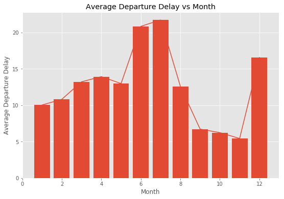

```python
matplotlib.style.use('ggplot')
fig_month = plt.figure(figsize=(9,6))
props_axes = {
    'title': 'Average Departure Delay vs Month',
    'xlabel': 'Month',
    'ylabel': 'Average Departure Delay'
}
axes = fig_month.add_subplot(111)
axes.set(**props_axes)
_ = axes.plot(grouped_data_season)
_ = axes.bar(grouped_data_season.index.values, grouped_data_season.dep_delay)
```

There seem to be seasonal patterns in the departure delays. The average departure delays are the lowest in the months of the Autumn/Fall season (September, October, November), with higher values in the Summer (June, July). Going by the mean delay values, the best month to leave New York would be November, and the worst month would be July.

(d) On average, how do departure delays vary over the course of a day?

```python
#Compute average departure delays by hour of the day
grouped_data_day = flights_df.groupby(['hour']).agg({'dep_delay': 'mean'})
grouped_data_day
```

| hour | dep_delay |
| --- | --- |
| 0.0 | 128.642452 |
| 1.0 | 207.049327 |
| 2.0 | 239.921875 |
| 3.0 | 304.727273 |
| 4.0 | -5.554098 |
| 5.0 | -4.355644 |
| 6.0 | -1.520552 |
| 7.0 | 0.223289 |
| 8.0 | 1.091432 |
| 9.0 | 4.268295 |
| 10.0 | 5.548644 |
| 11.0 | 5.652309 |
| 12.0 | 7.601892 |
| 13.0 | 9.380639 |
| 14.0 | 8.090381 |
| 15.0 | 10.682049 |
| 16.0 | 13.621150 |
| 17.0 | 16.756593 |
| 18.0 | 18.664671 |
| 19.0 | 21.497342 |
| 20.0 | 28.266213 |
| 21.0 | 42.064964 |
| 22.0 | 68.190042 |
| 23.0 | 96.946865 |
| 24.0 | 64.862069 |

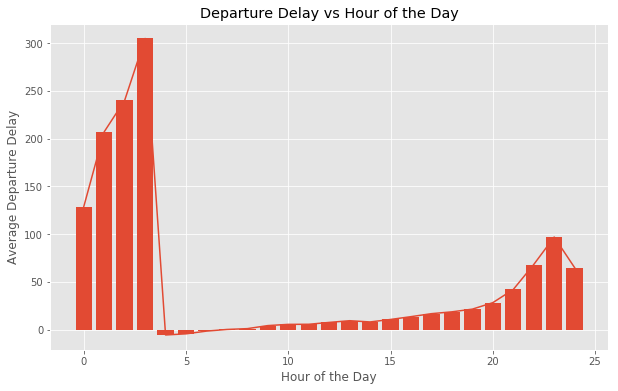

```python
matplotlib.style.use('ggplot')
fig_hour = plt.figure(figsize=(10,6))
props_axes = {
    'title': 'Departure Delay vs Hour of the Day',
    'xlabel': 'Hour of the Day',
    'ylabel': 'Average Departure Delay'
}
axes = fig_hour.add_subplot(111)
axes.set(**props_axes)
_ = axes.plot(grouped_data_day)
_ = axes.bar(grouped_data_day.index.values, grouped_data_day['dep_delay'])
```

The average departure delays are generally high during late night hours. We see very small, even negative departure delays in the morning from about 4 AM, which then keep increasing as the days progresses, peaking at 10-11 PM. The highest delays are observed post midnight, with flights between 2-3 AM having an average delay of 304 minutes.

## Question 3

Which flight departing NYC in 2013 flew the fastest?

```python
#Calculate the speed for each flight as a new column in the dataframe
flights_df['speed'] = flights_df['distance']/(flights_df['air_time']/60)
flights_df.sort_values(by=['speed'], ascending = False).head(1)[['date', 'carrier', 'flight', 'origin', 'dest', 'speed']]
```

|  | date | carrier | flight | origin | dest | speed |
| --- | --- | --- | --- | --- | --- | --- |
| 216447 | 5/25/2013 | DL | 1499 | LGA | ATL | 703.384615 |

Flight 1499 operated by Delta Airlines (DL) and traveling from LaGuardia airport to Atlanta on May 25, 2013 was the fastest flight departing NYC.

## Question 4

Which flights (i.e. carrier + flight + dest) happen every day? Where do they fly to?

```python
#Group flights by air carrier, flight number and destination, and calculate counts for each such combination
flights_df_counts = pd.DataFrame(flights_df.groupby(['carrier', 'flight', 'dest']).flight.count())
flights_df_counts.rename(columns = {'flight':'count'}, inplace = True)
#The code below assumes that each flight number would not be flying more than once per day
flights_temp = flights_df_counts[flights_df_counts['count'] >= 365]
flights_temp.reset_index(inplace = True)
flights_temp[['carrier', 'flight', 'dest']]
```

|  | carrier | flight | dest |
| --- | --- | --- | --- |
| 0 | AA | 59 | SFO |
| 1 | AA | 119 | LAX |
| 2 | AA | 181 | LAX |
| 3 | AA | 1357 | SJU |
| 4 | AA | 1611 | MIA |
| 5 | B6 | 219 | CLT |
| 6 | B6 | 359 | BUR |
| 7 | B6 | 371 | FLL |
| 8 | B6 | 431 | SRQ |
| 9 | B6 | 703 | SJU |
| 10 | B6 | 1783 | MCO |
| 11 | DL | 2159 | MCO |
| 12 | DL | 2391 | TPA |
| 13 | EV | 5712 | IAD |
| 14 | UA | 15 | HNL |
| 15 | VX | 251 | LAS |
| 16 | VX | 407 | LAX |
| 17 | VX | 413 | LAX |

There are 18 flights that are scheduled daily. These fly from NYC to the following unique destinations:

1. SFO - San Francisco (CA)
2. LAX - Los Angeles (CA)
3. SJU - San Juan (Puerto Rico)
4. MIA - Miami (FL)
5. CLT - Charlotte (NC)
6. BUR - Burbank (CA)
7. FLL - Fort Lauderdale (FL)
8. SRQ - Sarasota (FL)
9. MCO - Orlando (FL)
10. TPA - Tampa (FL)
11. IAD - Dulles (VA)
12. HNL - Honolulu (HI)
13. LAS - Las Vegas (NV)

The most number of destinations covered in these daily flights are from Florida (5).

## Question 5

Develop one research question you can address using the nycflights2013 dataset. Provide two visualizations to support your exploration of this question. Discuss what you find.

**Research Question: “Considering departure delays, what are the worst performing airlines flying from New York in the year 2013?”**

*Preparing data for visualizations*

```python
#Prepare data for Plot 1 (Box plot for airline vs departure delays)
#Extract the series of unique airlines
carriers_unique = flights_df['carrier'].unique()
carrier_delays = []
for carrier in carriers_unique:
    #Extract non-null delays for each airline into a new list
    carrier_delays.append(list(flights_df[np.logical_and(flights_df['carrier'] == carrier,
                                                         pd.notnull(flights_df['dep_delay']))]['dep_delay']))

#Prepare data for Plot 2 (Average departure delays by airline)
carriers_avg_delays = pd.DataFrame(flights_df.groupby(['carrier']).dep_delay.mean())
carriers_avg_delays.reset_index(level = 0, inplace = True)

#Prepare data for Plot 3 (Percent of flights delayed by airline)
#Extract count of flights by airline
flights_count_airline = pd.DataFrame(flights_df.groupby(['carrier']).flight.count())
flights_count_airline.reset_index(level = 0, inplace = True)
#Extract count of delayed flights by airline
flights_delaycount_airline = pd.DataFrame(flights_df[np.logical_and(pd.notnull(flights_df['dep_delay']),
                                                                    flights_df['dep_delay'] > 0)]
                                          .groupby(['carrier']).flight.count())
flights_delaycount_airline.reset_index(level = 0, inplace = True)
#Merge the data for the two counts into a single dataframe
carrier_counts = pd.merge(flights_count_airline, flights_delaycount_airline, on='carrier')
carrier_counts.rename(columns={'flight_x': 'total_count', 'flight_y': 'delay_count'}, inplace=True)
#Compute the percent of flights delayed based on the above two counts
carrier_counts['percent_delays'] = carrier_counts['delay_count']/carrier_counts['total_count'] * 100
```

*Creating visualizations*

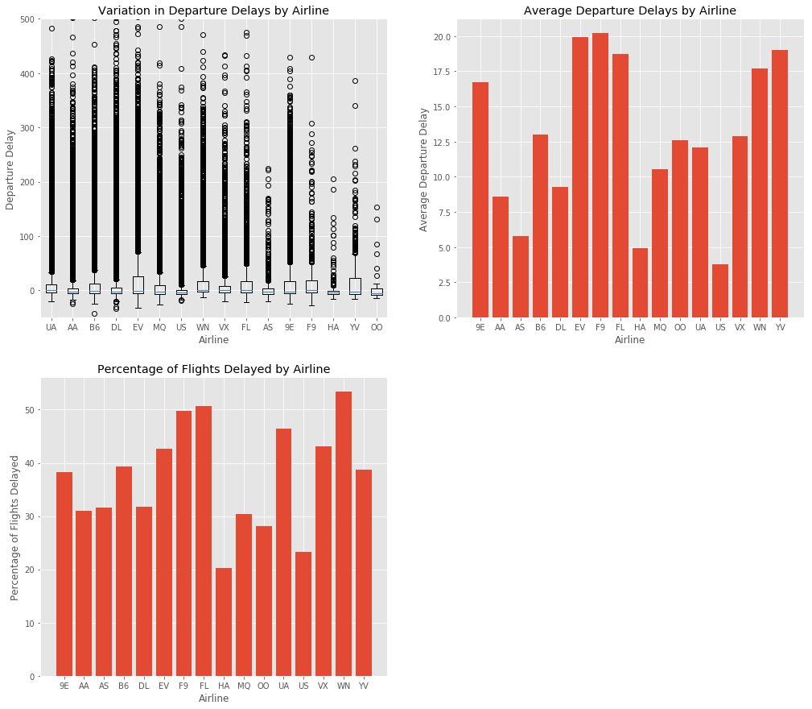

```python
#Plot 1 (Box plot for airline vs departure delays)
matplotlib.style.use('ggplot')
fig = plt.figure(figsize=(17,15))
ax1 = fig.add_subplot(2,2,1)
ax1.set_ylim((-50, 500))
props_ax1 = {
    'title': 'Variation in Departure Delays by Airline',
    'xlabel': 'Airline',
    'ylabel': 'Departure Delay'
}
ax1.set(**props_ax1)
_ = ax1.boxplot(carrier_delays, labels = carriers_unique)

#Plot 2 (Average departure delays by airline)
props_ax2 = {
    'title': 'Average Departure Delays by Airline',
    'xlabel': 'Airline',
    'ylabel': 'Average Departure Delay'
}
ax2 = fig.add_subplot(2,2,2)
ax2.set(**props_ax2)
_ = ax2.bar(carriers_avg_delays['carrier'], carriers_avg_delays['dep_delay'])

#Plot 3 (Percent of flights delayed by airline)
props_ax3 = {
    'title': 'Percentage of Flights Delayed by Airline',
    'xlabel': 'Airline',
    'ylabel': 'Percentage of Flights Delayed'
}
ax3 = fig.add_subplot(2,2,3)
ax3.set(**props_ax3)
_ = ax3.bar(carrier_counts['carrier'], carrier_counts['percent_delays'])
```

*Interpretation*

1. In terms of the average departure delays (plot 2 above), airline F9 (Frontier Airlines) seems to be doing the worst, closely matched by airline EV (Atlantic Southeast Airlines).
2. However, looking at the box plot, the airline EV seems to be more unpredicatable than F9 in terms of the delays, showing more variability in adherance to departure times. Consistent performance could be an important factor for passengers.
3. Looking at the last plot however, we see that the airline WN (Southwest Airlines), beats both EV and F9, and has the highest percentage of flights delayed, out of the total flights operated.

Therefore, there doesn't seem to be one clear worst performing airline. Depending on the criteria, we have different candidates for poor performance in terms of departure delays, namely, Atlantic Southeast Airlines, Frontier Airlines, and Southwest Airlines

## Question 6

What weather conditions are associated with flight delays leaving NYC? Use graphics to explore.

```python
#Import and explore the weather data
weather_df= pd.read_csv('weather.csv.bz2')
weather_df.head(5)
```

|  | Unnamed: 0 | origin | year | month | day | hour | temp | dewp | humid | wind_dir | wind_speed | wind_gust | precip | pressure | visib |
| --- | --- | --- | --- | --- | --- | --- | --- | --- | --- | --- | --- | --- | --- | --- | --- |
| 0 | 1 | EWR | 2013 | 1.0 | 1.0 | 0.0 | 37.04 | 21.92 | 53.97 | 230.0 | 10.35702 | 11.918651 | 0.0 | 1013.9 | 10.0 |
| 1 | 2 | EWR | 2013 | 1.0 | 1.0 | 1.0 | 37.04 | 21.92 | 53.97 | 230.0 | 13.80936 | 15.891535 | 0.0 | 1013.0 | 10.0 |
| 2 | 3 | EWR | 2013 | 1.0 | 1.0 | 2.0 | 37.94 | 21.92 | 52.09 | 230.0 | 12.65858 | 14.567241 | 0.0 | 1012.6 | 10.0 |
| 3 | 4 | EWR | 2013 | 1.0 | 1.0 | 3.0 | 37.94 | 23.00 | 54.51 | 230.0 | 13.80936 | 15.891535 | 0.0 | 1012.7 | 10.0 |
| 4 | 5 | EWR | 2013 | 1.0 | 1.0 | 4.0 | 37.94 | 24.08 | 57.04 | 240.0 | 14.96014 | 17.215830 | 0.0 | 1012.8 | 10.0 |

```python
#Set defined integer values for unknowns
weather_df.month = weather_df.month.fillna(0).astype(int)
weather_df.day = weather_df.day.fillna(0).astype(int)
weather_df.hour = weather_df.hour.fillna(-1).astype(int)
```

```python
#Group flights data on a per day basis
flights_daily_df = pd.DataFrame(flights_df.groupby(['date']).dep_delay.mean())
flights_daily_df.reset_index(level = 0, inplace = True)
#Add a date column to the weather data
weather_df['date'] = weather_df['month'].map(str) + '/' + weather_df['day'].map(str) + '/' + weather_df['year'].map(str)
#Group weather data on a per day basis to make the grain same as that for the flights data
weather_daily_df = weather_df.groupby(['date']).mean()
weather_daily_df.reset_index(level = 0, inplace = True)
```

```python
#Perform a left join on the flights and weather data, so as to not lose out on flights data for which weather information
#is not available
merged_df = pd.merge(flights_daily_df, weather_daily_df, on=['date'], how = 'left')
del merged_df['Unnamed: 0']
```

```python
#Print the correlations of the various weather related variables, with departure delay
merged_df[['dep_delay', 'temp', 'dewp', 'humid', 'wind_dir', 'wind_speed', 'wind_gust', 'precip', 'pressure', 'visib']].corr()
```

|  | dep_delay | temp | dewp | humid | wind_dir | wind_speed | wind_gust | precip | pressure | visib |
| --- | --- | --- | --- | --- | --- | --- | --- | --- | --- | --- |
| dep_delay | 1.000000 | 0.191265 | 0.318084 | 0.469157 | -0.184788 | -0.028827 | -0.028827 | 0.358360 | -0.267897 | -0.408949 |
| temp | 0.191265 | 1.000000 | 0.947855 | 0.246186 | -0.151778 | -0.234153 | -0.234153 | -0.009730 | -0.265133 | 0.111572 |
| dewp | 0.318084 | 0.947855 | 1.000000 | 0.538505 | -0.284759 | -0.295837 | -0.295837 | 0.115790 | -0.310673 | -0.103490 |
| humid | 0.469157 | 0.246186 | 0.538505 | 1.000000 | -0.466447 | -0.283466 | -0.283466 | 0.408797 | -0.261423 | -0.673389 |
| wind_dir | -0.184788 | -0.151778 | -0.284759 | -0.466447 | 1.000000 | 0.470056 | 0.470056 | -0.154772 | -0.255505 | 0.348407 |
| wind_speed | -0.028827 | -0.234153 | -0.295837 | -0.283466 | 0.470056 | 1.000000 | 1.000000 | 0.002506 | -0.253861 | 0.145128 |
| wind_gust | -0.028827 | -0.234153 | -0.295837 | -0.283466 | 0.470056 | 1.000000 | 1.000000 | 0.002506 | -0.253861 | 0.145128 |
| precip | 0.358360 | -0.009730 | 0.115790 | 0.408797 | -0.154772 | 0.002506 | 0.002506 | 1.000000 | -0.191252 | -0.462270 |
| pressure | -0.267897 | -0.265133 | -0.310673 | -0.261423 | -0.255505 | -0.253861 | -0.253861 | -0.191252 | 1.000000 | 0.122892 |
| visib | -0.408949 | 0.111572 | -0.103490 | -0.673389 | 0.348407 | 0.145128 | 0.145128 | -0.462270 | 0.122892 | 1.000000 |

The above correlations suggest that there might be an association worth exploring, between the departure delay and factors such as dew point, humidity, precipitation and visibility. In order to explore this, we create scatter plots for these variables and departure delay below. Further, we also note that the dew point is highly correlated to the temperature (as one would intuitively expect).

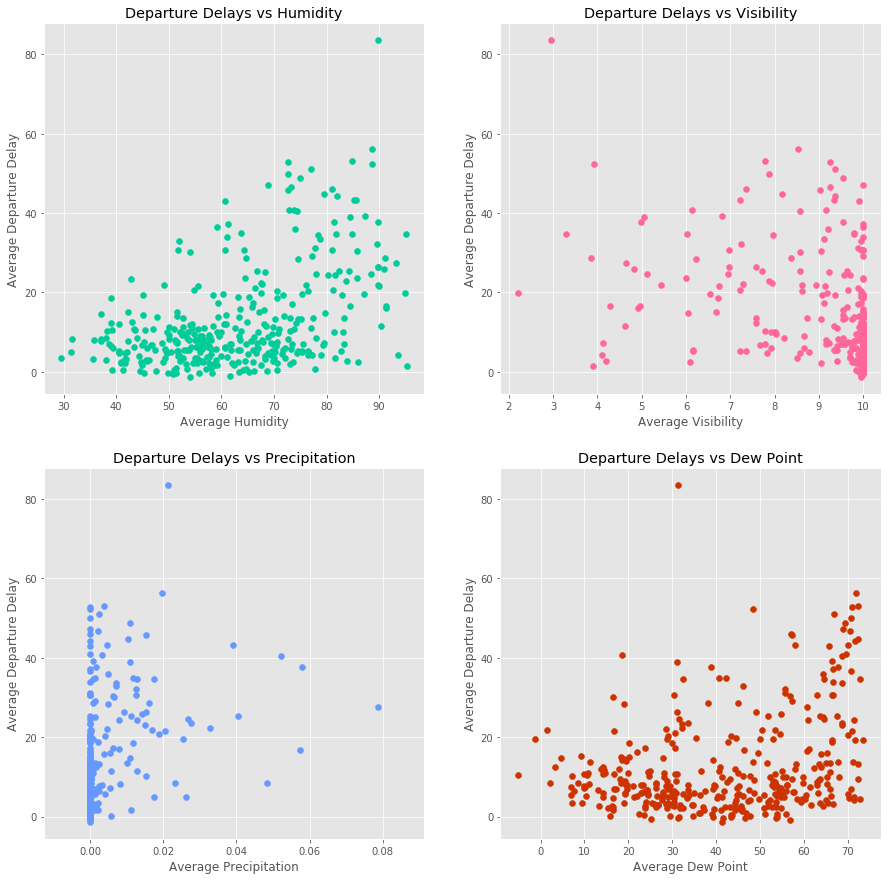

```python
matplotlib.style.use('ggplot')
fig_weather = plt.figure(figsize=(15,15))
axes1 = fig_weather.add_subplot(2,2,1)
props_axes1 = {
    'title': 'Departure Delays vs Humidity',
    'xlabel': 'Average Humidity',
    'ylabel': 'Average Departure Delay'
}
axes1.set(**props_axes1)
_ = axes1.scatter(merged_df['humid'], merged_df['dep_delay'], c = '#00cc99')
axes2 = fig_weather.add_subplot(2,2,2)
props_axes2 = {
    'title': 'Departure Delays vs Visibility',
    'xlabel': 'Average Visibility',
    'ylabel': 'Average Departure Delay'
}
axes2.set(**props_axes2)
_ = axes2.scatter(merged_df['visib'], merged_df['dep_delay'], c = '#ff6699')
axes3 = fig_weather.add_subplot(2,2,3)
props_axes3 = {
    'title': 'Departure Delays vs Precipitation',
    'xlabel': 'Average Precipitation',
    'ylabel': 'Average Departure Delay'
}
axes3.set(**props_axes3)
_ = axes3.scatter(merged_df['precip'], merged_df['dep_delay'], c = '#6699ff')
axes4 = fig_weather.add_subplot(2,2,4)
props_axes4 = {
    'title': 'Departure Delays vs Dew Point',
    'xlabel': 'Average Dew Point',
    'ylabel': 'Average Departure Delay'
}
axes4.set(**props_axes4)
_ = axes4.scatter(merged_df['dewp'], merged_df['dep_delay'], c = '#cc3300')
```

The above plots are in agreement with what the correlations suggested:

1. There is a positive correlation between humidity and average departure delay, with days having lower humidity levels showing lower delay times.
2. There is a slight negative assocation of the departure delays with visibility, which one would expect intuitively. Days having higher (good visibility) reported lower departure delay times.
3. For precipitation, most of the data points are cluttered in the area of low precipitation values, with a lot of variation in departure delays, therefore it seems hard to establish an association.
4. Lastly, the average departure delays seem to increase slightly, as the dew point increases.

In our analysis earlier, we had found that the months expected to have high temperatures (June and July) had the highest average departure delays. Moreover, we found above that the dew point has a positive correlation with departure delays as well as with temperature. Therefore, it can be worthwhile to further explore month-wise delays against temperature.

```python
#Compute total count of flights by month
flights_count_month = pd.DataFrame(flights_df.groupby(['month']).flight.count())
flights_count_month.reset_index(level = 0, inplace = True)
#Compute count of delayed flights by month
flights_delaycount_month = pd.DataFrame(flights_df[np.logical_and(pd.notnull(flights_df['dep_delay']),
                                                                  flights_df['dep_delay'] > 0)].groupby(['month']).flight.count())
flights_delaycount_month.reset_index(level = 0, inplace = True)
#Merge the total and delayed flight counts and calculate percentage of flight delays by month
monthly_counts = pd.merge(flights_count_month, flights_delaycount_month, on='month')
monthly_counts.rename(columns={'flight_x': 'total_count', 'flight_y': 'delay_count'}, inplace=True)
monthly_counts['percent_delays'] = carrier_counts['delay_count']/carrier_counts['total_count'] * 100
```

```python
#Create final merged data frame with relevant fields for month-wise analysis
merged_df_monthly = merged_df[['dep_delay', 'year', 'month', 'temp', 'dewp', 'humid', 'wind_dir',
                               'wind_speed', 'wind_gust', 'precip', 'pressure', 'visib']].groupby(['year','month']).mean()
merged_df_monthly.reset_index(inplace = True)
merged_df_monthly['month'] = merged_df_monthly['month'].astype(int)
#Merge the monthly flight and delay counts data above into the final data frame for analysis
merged_df_monthly = pd.merge(merged_df_monthly, monthly_counts, on = 'month', how = 'inner')
```

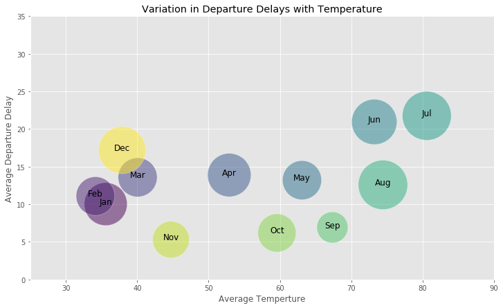

```python
matplotlib.style.use('ggplot')
fig_monthly = plt.figure(figsize=(12, 7))
axes1 = fig_monthly.add_subplot(111)
axes1.set_ylim((0, 35))
axes1.set_xlim((25, 90))
props_axes1 = {
    'title': 'Variation in Departure Delays with Temperature',
    'xlabel': 'Average Temperture',
    'ylabel': 'Average Departure Delay'
}
axes1.set(**props_axes1)
scatter_plot = axes1.scatter(merged_df_monthly['temp'], merged_df_monthly['dep_delay'],
                             s = merged_df_monthly['percent_delays'] * 100, c = merged_df_monthly['month'], edgecolor='w',
                             alpha = 0.5)
months_list = ['Jan','Feb','Mar','Apr','May','Jun','Jul','Aug','Sep','Oct','Nov','Dec']
series_x = merged_df_monthly['temp'];
series_y = merged_df_monthly['dep_delay']
idx = 0
while idx < len(months_list):
    axes1.text(series_x[idx], series_y[idx], months_list[idx], size=12, horizontalalignment='center')
    idx = idx+1
```